# Legionellosis: County and Population in Ohio

David Hibler

December 3, 2019

# Data

## Obtaining and Processing the Data

pop_2010 = Ohio county population from [2010 census](https://www.census.gov/quickfacts/OH).  
pop_2018 = [Estimated Ohio county population](http://worldpopulationreview.com/states/ohio/). Retrieved 2019-01-24, from http://worldpopulationreview.com/states/ohio/  
pop_dens = Population density calculated from 2018 population and county area in sq miles.  
ln_2018_pop = The calculated natural log of the 2018 population.  
ln_pop_density = The calculated natural log of the 2018 population density.  
pop_dif = The calculated change in population from 2010 to 2018.  
abs_pop_dif = The absolute value of change in population from 2010 to 2018.  
l_2017 = Reported Legionellosis infections in 2017 gathered from the [Ohio Department of Health Infections Diseases Report](https://odh.ohio.gov/wps/portal/gov/odh/know-our-programs/infectious-diseases/Reports/2017-annual-summary).  
l_2018 = Reported Legionellosis infections in 2018 that was specially disclosed by the Ohio Department of Health and is not yet available online, so was not used in this project.

Data set calculations (such as population densities and natural logs) were done in excell and then the data set was saved as a csv file to be analyzed in R.

## Analyzing the Data

Data sets were ploted for visual examination, and correlational tests (such as Pearson’s, Kendall’s, and Spearman’s) were run to check for signifigance.

```r
set.seed(37)

setwd("C:/Users/hible/Documents/School/Pubhealth/PUBHLTH 8802 - GISD sem")

my_data <- read.csv("ohio_ld_2018.csv", header=TRUE)

l_2017_v <- my_data$l_2017
pop_2018_v <- my_data$pop_2018
pop_density_v <- my_data$pop_density
ln_2018_pop_v <- my_data$ln_2018_pop
ln_pop_density_v <- my_data$ln_pop_density

cor_p_values <- matrix(nrow=3, ncol=4)
colnames(cor_p_values) <- c("Infections vs Population", "Infections vs Pop_density", "Infections vs Ln_Pop", "Infections vs Ln_Pop_density")
rownames(cor_p_values) <- c("Pearson", "Kendall", "Spearman")

i_p_p <- cor.test(l_2017_v,pop_2018_v, method = "pearson")
cor_p_values[1,1] <- i_p_p$p.value
i_p_k <- cor.test(l_2017_v,pop_2018_v, method = "kendall")
cor_p_values[2,1] <- i_p_k$p.value
i_p_s <- cor.test(l_2017_v,pop_2018_v, method = "spearman")
cor_p_values[3,1] <- i_p_s$p.value

i_p_p <- cor.test(l_2017_v,pop_density_v, method = "pearson")
cor_p_values[1,2] <- i_p_p$p.value
i_p_k <- cor.test(l_2017_v,pop_density_v, method = "kendall")
cor_p_values[2,2] <- i_p_k$p.value
i_p_s <- cor.test(l_2017_v,pop_density_v, method = "spearman")
cor_p_values[3,2] <- i_p_s$p.value

i_p_p <- cor.test(l_2017_v,ln_2018_pop_v, method = "pearson")
cor_p_values[1,3] <- i_p_p$p.value
i_p_k <- cor.test(l_2017_v,ln_2018_pop_v, method = "kendall")
cor_p_values[2,3] <- i_p_k$p.value
i_p_s <- cor.test(l_2017_v,ln_2018_pop_v, method = "spearman")
cor_p_values[3,3] <- i_p_s$p.value

cor.test(l_2017_v,ln_pop_density_v, method = "pearson")
```

```
##
##  Pearson's product-moment correlation
##
## data:  l_2017_v and ln_pop_density_v
## t = 7.8433, df = 86, p-value = 1.096e-11
## alternative hypothesis: true correlation is not equal to 0
## 95 percent confidence interval:
##  0.5045721 0.7533242
## sample estimates:
##       cor
## 0.6457702
```

```r
i_p_p <- cor.test(l_2017_v,ln_pop_density_v, method = "pearson")
cor_p_values[1,4] <- i_p_p$p.value
i_p_k <- cor.test(l_2017_v,ln_pop_density_v, method = "kendall")
cor_p_values[2,4] <- i_p_k$p.value
i_p_s <- cor.test(l_2017_v,ln_pop_density_v, method = "spearman")
cor_p_values[3,4] <- i_p_s$p.value

print(cor_p_values)
```

```
##          Infections vs Population Infections vs Pop_density
## Pearson              1.425785e-39              2.109105e-30
## Kendall              4.891875e-14              1.331731e-13
## Spearman             1.727944e-15              1.073629e-14
##          Infections vs Ln_Pop Infections vs Ln_Pop_density
## Pearson          5.435431e-12                 1.096061e-11
## Kendall          4.891875e-14                 1.331731e-13
## Spearman         1.727944e-15                 1.073629e-14
```

Infections were found to be highly significantly correlated with population size, population density,the natural log of the population size, and the natuarl log of the population density.

# Summary stats

```r
# summarize the data
summary(my_data)
```

```
##      Ã¯..county       area           l_2018          pop_2010
##  Adams    : 1   Min.   :228.2   Min.   :  0.00   Min.   :  13319
##  Allen    : 1   1st Qu.:409.5   1st Qu.:  1.00   1st Qu.:  37312
##  Ashland  : 1   Median :439.1   Median :  3.00   Median :  57733
##  Ashtabula: 1   Mean   :464.4   Mean   : 10.57   Mean   : 131368
##  Athens   : 1   3rd Qu.:510.5   3rd Qu.:  8.00   3rd Qu.: 124145
##  Auglaize : 1   Max.   :702.4   Max.   :208.00   Max.   :1267513
##  (Other)  :82
##     pop_2018        pop_density       ln_2018_pop     ln_pop_density
##  Min.   :  13142   Min.   :  31.26   Min.   : 9.484   Min.   :3.442
##  1st Qu.:  36946   1st Qu.:  83.94   1st Qu.:10.517   1st Qu.:4.429
##  Median :  57786   Median : 119.11   Median :10.964   Median :4.780
##  Mean   : 131929   Mean   : 292.84   Mean   :11.169   Mean   :5.047
##  3rd Qu.: 123526   3rd Qu.: 256.16   3rd Qu.:11.724   3rd Qu.:5.546
##  Max.   :1257401   Max.   :2742.48   Max.   :14.045   Max.   :7.917
##
##     pop_dif          abs_pop_dif        l_2017           inf_dif
##  Min.   :-10112.0   Min.   :    2   Min.   :  0.000   Min.   :-6.000
##  1st Qu.:  -633.5   1st Qu.:  244   1st Qu.:  1.000   1st Qu.: 0.000
##  Median :  -256.5   Median :  583   Median :  2.000   Median : 1.000
##  Mean   :   561.2   Mean   : 1880   Mean   :  6.602   Mean   : 3.966
##  3rd Qu.:    97.5   3rd Qu.: 1375   3rd Qu.:  5.000   3rd Qu.: 4.250
##  Max.   : 55915.0   Max.   :55915   Max.   :123.000   Max.   :85.000
##
```

```r
mean(my_data$l_2017)
```

```
## [1] 6.602273
```

```r
mean(my_data$pop_2018)
```

```
## [1] 131929
```

```r
mean(my_data$pop_density)
```

```
## [1] 292.8386
```

```r
mean(my_data$ln_2018_pop)
```

```
## [1] 11.16865
```

```r
mean(my_data$ln_pop_density)
```

```
## [1] 5.046705
```

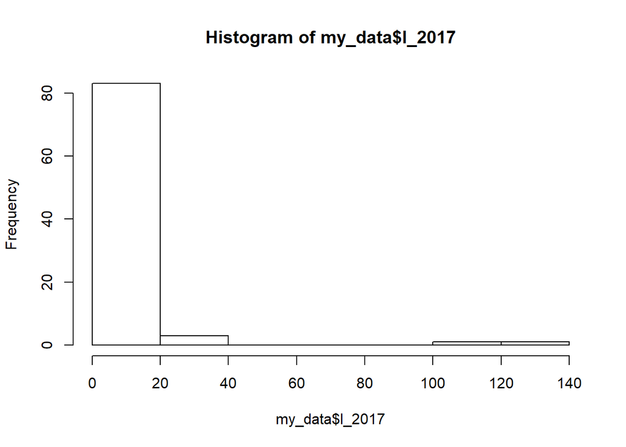

```r
# histograms
hist(my_data$l_2017)
```

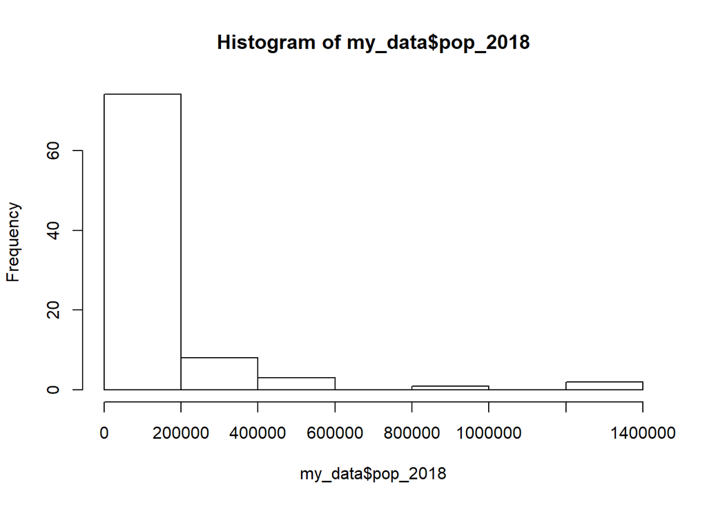

```r
hist(my_data$pop_2018)
```

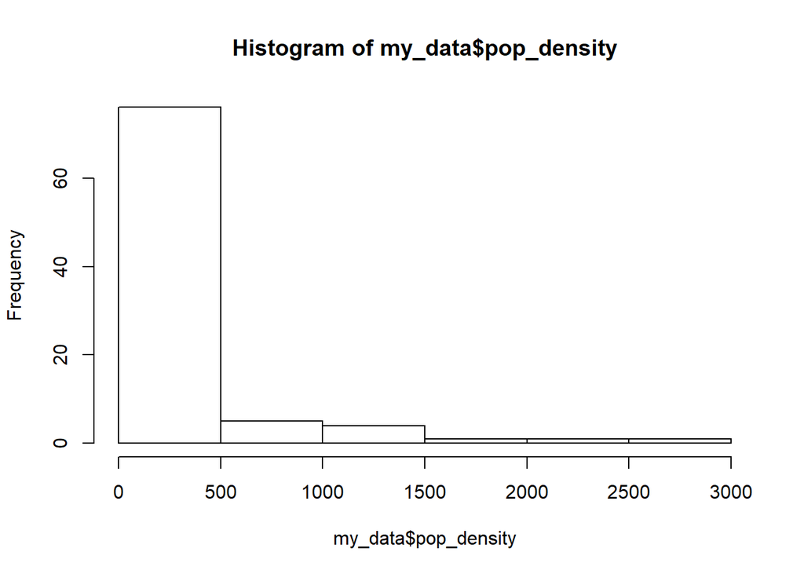

```r
hist(my_data$pop_density)
```

```r
# variances, these should match what we supplied in the covariance matrix
var(my_data$l_2017)
```

```
## [1] 317.7825
```

```r
var(my_data$pop_2018)
```

```
## [1] 46858858822
```

```r
var(my_data$pop_density)
```

```
## [1] 222635.3
```

# Plot

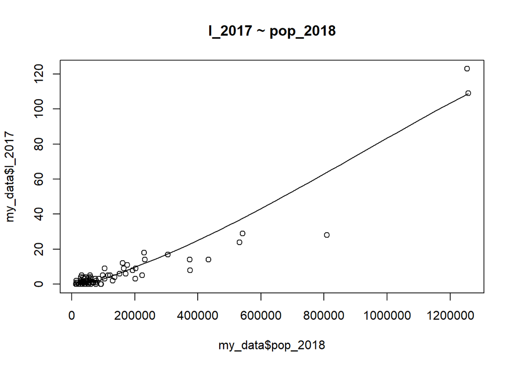

```r
scatter.smooth(x=my_data$pop_2018, y=my_data$l_2017, main="l_2017 ~ pop_2018")
```

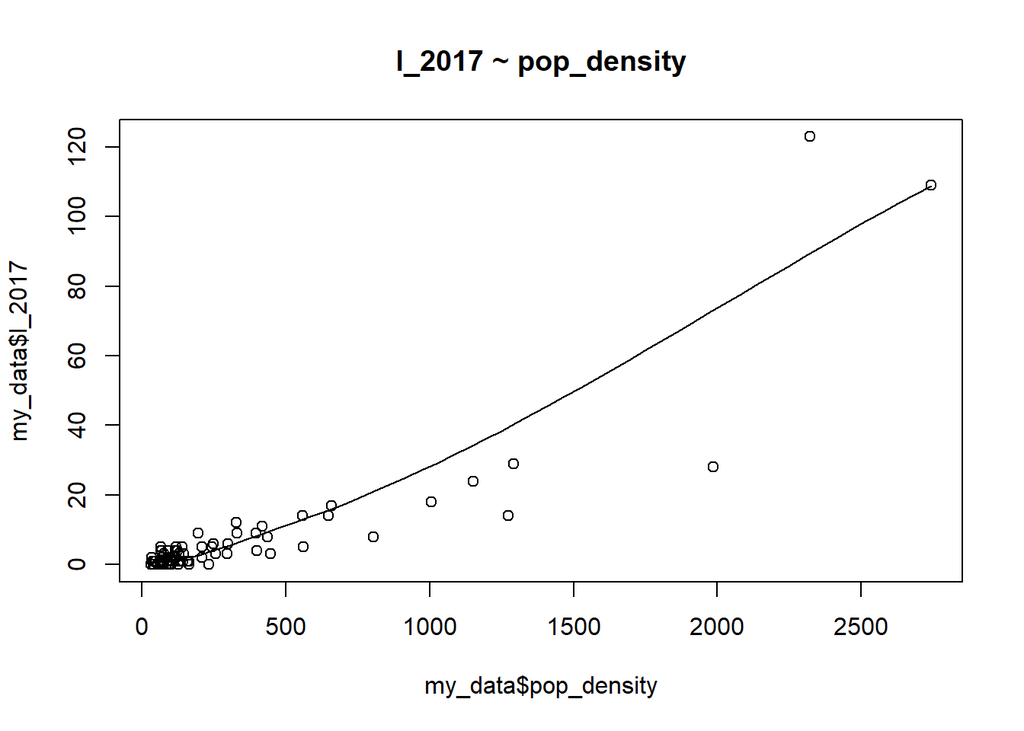

```r
scatter.smooth(x=my_data$pop_density, y=my_data$l_2017, main="l_2017 ~ pop_density")
```

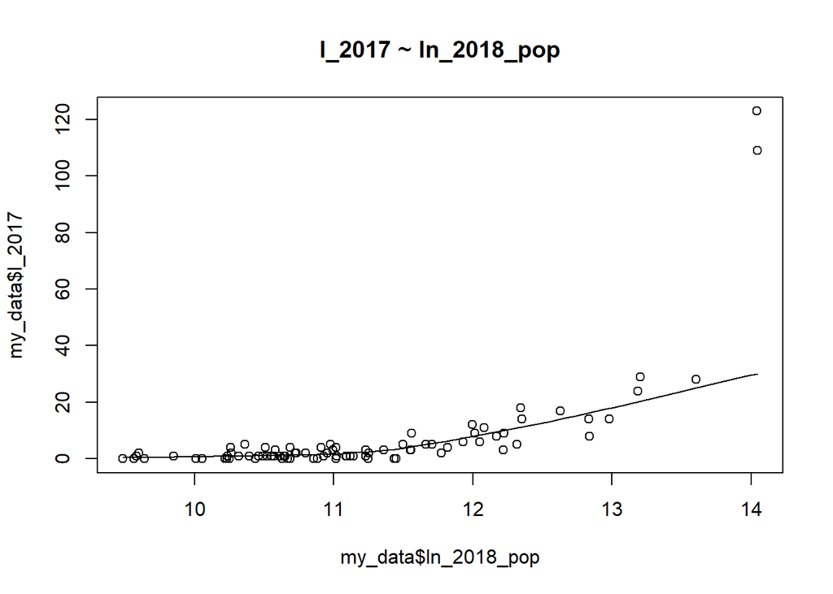

```r
scatter.smooth(x=my_data$ln_2018_pop, y=my_data$l_2017, main="l_2017 ~ ln_2018_pop")
```

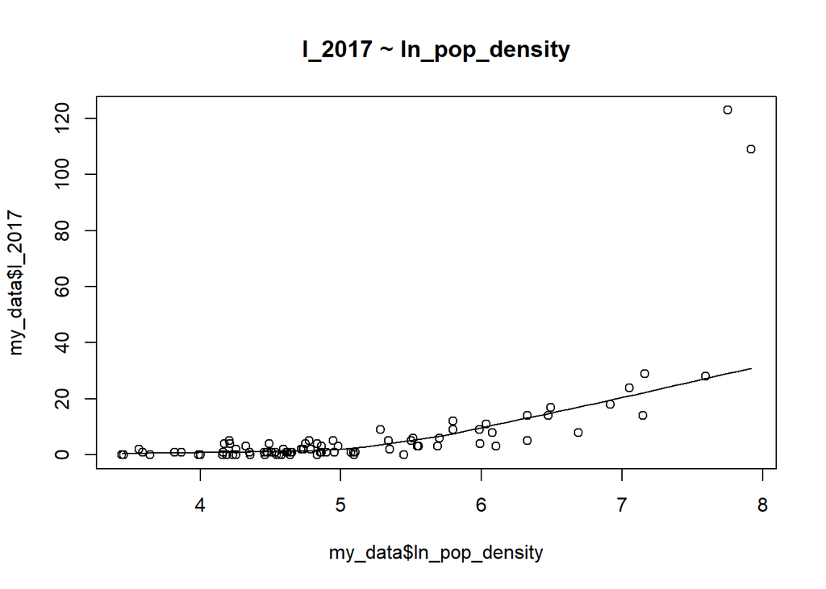

```r
scatter.smooth(x=my_data$ln_pop_density, y=my_data$l_2017, main="l_2017 ~ ln_pop_density")
```

# Linear regression

```r
linearMod_pop <- lm(l_2017 ~ pop_2018, data=my_data)  # build linear regression model on full data
print(linearMod_pop)
```

```
##
## Call:
## lm(formula = l_2017 ~ pop_2018, data = my_data)
##
## Coefficients:
## (Intercept)     pop_2018
##  -3.520e+00    7.672e-05
```

```r
linearMod_popd <- lm(l_2017 ~ pop_density, data=my_data)  # build linear regression model on full data
print(linearMod_popd)
```

```
##
## Call:
## lm(formula = l_2017 ~ pop_density, data = my_data)
##
## Coefficients:
## (Intercept)  pop_density
##    -3.19690      0.03346
```

```r
linearMod_lnpop <- lm(l_2017 ~ ln_2018_pop, data=my_data)  # build linear regression model on full data
print(linearMod_lnpop)
```

```
##
## Call:
## lm(formula = l_2017 ~ ln_2018_pop, data = my_data)
##
## Coefficients:
## (Intercept)  ln_2018_pop
##     -123.59        11.66
```

```r
linearMod_lnpopd <- lm(l_2017 ~ ln_pop_density, data=my_data)  # build linear regression model on full data
print(linearMod_lnpopd)
```

```
##
## Call:
## lm(formula = l_2017 ~ ln_pop_density, data = my_data)
##
## Coefficients:
##    (Intercept)  ln_pop_density
##         -51.54           11.52
```